# Does the red effect really exist?

*N* removed NAs: 3

*N* removed <18: 20

*N* total clean: 124

| Group | *N* | *M*<sub>age</sub> | *M*<sub>rating</sub> |
| --- | --- | --- | --- |
| Control | 57 | 21.0 | 7.08 |
| Experim | 67 | 20.8 | 6.07 |

**Main analysis results**

*t*(122) = 7.81, *p* < .001

# Does the red effect really exist?

Analysing Data, Spring 2020

# Methods

## Design

Our study wanted to ask the question “Does colour influence attractiveness?” The study utilised an independent groups design with colour being the independent categorical variable. It had two levels – the experimental group viewed a black and white photo of a man on a red background, whilst the control group viewed the same picture but on a white background. Afterwards, they rated the man on his perceived attractiveness (this was the continuous variable). This was done in a standardised way – each participant was asked the same three questions: “How attractive do you think this person is?” “How pleasant is this person to look at?” and “If I were to meet the person in this picture face to face, I would think he is attractive.” Participants were required to give a number on a rating-scale of 1 (not at all attractive) to 9 (extremely attractive). Finally, the scores given across the 3 questions were averaged to give a composite index.

Our operational hypothesis was, “Does viewing a different colour frame around an image of a moderately attractive man influence the mean ratings of his attractiveness?” The statistical test we will be using to analyse this is an independent measures t-test.

# Results

However, our graph contradicts the ‘red effect’, as those rating the man in the white frame gave (on average) higher attractiveness ratings than those rating the man surrounded by the red frame. Interestingly, this is the opposite of what our study originally predicted and thus suggests that the red effect (as first noted by Elliot et al, 2010) is not replicable and leads the way for explanations as to why this has occurred.

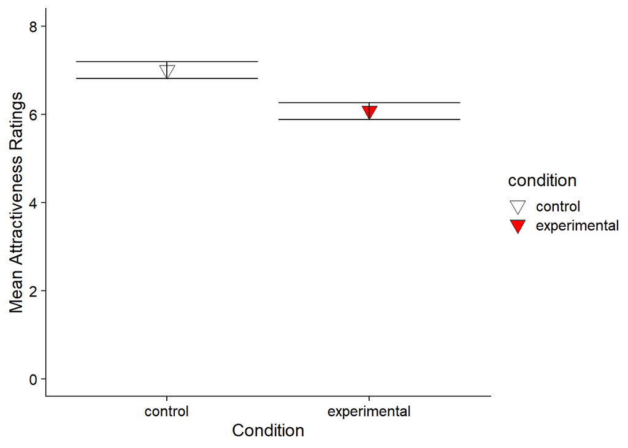

# Discussion

Our study set out to replicate the red effect to see if women’s attractiveness ratings of a man were affected by the colour of the frame by which his picture was surrounded. In a way it did this, but not in the way expected. In actual fact, women rated the man higher on average in the white frame than the red frame. This directly contradicts the red effect, which states that the colour red seems to make men who sport it more romantically attractive due to several biological and cultural reasons, namely passing it down through evolution and social learning throughout human history.

As mentioned, out study was a replication of the first experiment carried out by Elliot et al (2010). The results from that study differed from ours – men inside a red frame were rated higher than those inside a white one. There was roughly the same difference between the two groups, so both results can be shown to be significant. As our study followed an identical design, differing results could subtract from the credibility of the red effect. This is not to say the red effect isn’t true however, but is perhaps more of a criticism towards the study design than the concept itself. To expand, the validity of using a picture to rate a person’s attractiveness is not as high as it rather easily could be. Needless to say, the sensation of a person actually being in front of you and in your environment will bring out a much wider and more vivid sense of emotions and opinions compared to simply seeing them in a picture. Perhaps in future experiments the man who is being rated should actually be there to increase accuracy of actual feelings of attractiveness that cannot be brought out in a picture.

Another study that attempted to replicate Elliot et al’s was Hesslinger, Goldbach & Carbon (2015). The first of two experiments used the picture of the man surrounded by different colour frames – this found no evidence for the red effect. In the second experiment, they used a man wearing different colour clothing (but still a photo). This also raised concerns over the design of the experiment, noting that while the colour red again did not seem to have any effect on attractiveness ratings, the type of apparel did. More specifically, formal apparel appeared to boost the man’s ratings compared to that which was more casual. This poses questions for the ecological validity of the red effect. In reality, fashion, taste and trends in clothing have a large impact on a person’s image. That is to say, is a man wearing a red designer-branded jumper more attractive because of its colour or its style and connotations? Indeed, if this is the case, does this then disregard the biological element of the red effect? As mentioned, both of the experiments found no evidence for the red effect, however they both used photos instead of real-life examples. This seems to be the case in other studies, including Peperkoorn, L. S., Roberts, S. C., & Pollet, T. V. (2016) which also found no evidence of the red effect when rating photographs.

The repeated finding of non-association between the colour red and attractiveness in these studies suggests to us that the red effect is certainly not as prevalent and certain as Elliot et al portrayed. However, as mentioned before it is true that there are more valid ways to test whether the red effect is real or not. In order for future research to do this, more holistic testing needs to be carried out. Human attraction is extremely complicated and different from many other species. Complex social learning and structures are and have been in place for hundreds of thousands of years that shape the way we think and feel towards others. Phenomenon such as fashion, expectation and tradition have shaped the way we view colour and its association with our actions and aesthetic nature. Of course there is the argument for biological evolution and the function of the colour red to display certain reproductive values that would have benefitted those who sported it in the past (see R. A. Hill & Barton, 2005), but to reduce present-day human attraction down to this when we are exposed to constant social learning and influencing phenomena (namely the media) would be seriously reductionist and quite simply incompetent to ignore the effect of the environment in which we live. Therefore, changes need to be made to the design of the experiment to increase its ecological validity. This could involve rating a real life person, having the participants spend a longer amount of time with someone who displays the colour red more/less, or simply testing people from different cultures, cohorts and even time periods if possible (by employing a longitudinal study design) to account for differences between and changes in time and location.

To conclude, replications of Elliot et al (2010) have been shown to disprove the red effect and give contradicting evidence for it increases attraction between people. In our own study, the colour red around a picture of a man had no effect on increasing attraction between him and participants, in fact they rated the picture with him inside a white frame significantly higher. However, this is not to say the red effect does not exist. To really delve deeper into whether the effect is real or not, we must try to incorporate our understanding of the colour red in our biology and environment into our experimental method & design by increasing participant interaction with the target to more closely replicate conditions in which attraction forms in the real-world.

# References

Hesslinger, V. M., Goldbach, L., & Carbon, C.-C. (2015). Men in red: A reexamination of the red-attractiveness effect. Psychonomic Bulletin & Review, 22(4), 1142–1148. https://doi.org/10.3758/s13423-015-0866-8

Hill, R. A., & Barton, R. A. (2005). Red enhances human performance in contests. Nature, 435(7040), 293. https://doi.org/10.1038/435293a

Peperkoorn, L. S., Roberts, S. C., & Pollet, T. V. (2016). Revisiting the Red Effect on Attractiveness and Sexual Receptivity: No Effect of the Color Red on Human Mate Preferences. Evolutionary Psychology, 14(4), 1474704916673841. https://doi.org/10.1177/1474704916673841

Elliot, A. J., Niesta Kayser, D., Greitemeyer, T., Lichtenfeld, S., Gramzow, R. H., Maier, M. A., & Liu, H. (2010). Red, rank, and romance in women viewing men. Journal of Experimental Psychology: General, 139(3), 399-417. doi:http://dx.doi.org/10.1037/a0019689

(Hesslinger, Goldbach, & Carbon, 2015; Hill & Barton, 2005; Peperkoorn, Roberts, & Pollet, 2016; Elliot, A. J., Niesta Kayser, D., Greitemeyer, T., Lichtenfeld, S., Gramzow, R. H., Maier, M. A., & Liu, H. (2010))